# TsA with RNA

For hashed dataset, we need to demultiplex it to get subsets for each sample in the pool.

## basic setup

import packages

```python
%matplotlib inline
import os
import anndata
import matplotlib
import numpy as np
import scanpy as sc
import matplotlib.pyplot as plt
import demultiplexing as demux
```

set up sample name and io path

```python
# sample name and cellranger output path
sample = 'TsA_redo_wRNA_210426'
matrix_input = f'{sample}/lane_new/outs'
```

read data  
We will use scanpy to read, write and process the data.  
Scanpy takes both mtx and h5 format.  
For faster reading spead, we will read the filtered h5 file into an anndata object in this demo

```python
ann = sc.read_10x_h5(os.path.join(matrix_input,'filtered_feature_bc_matrix.h5'), gex_only=False)
```

```
Variable names are not unique. To make them unique, call `.var_names_make_unique`.
```

according to the warning message from scanpy, there are duplicate variable names  
we need to correct the variable names with the function mentioned

```python
ann.var_names_make_unique()
```

```python
# check the variable metadata
ann.var
```

|  | gene_ids | feature_types | genome |
| --- | --- | --- | --- |
| MIR1302-2HG | ENSG00000243485 | Gene Expression | GRCh38 |
| FAM138A | ENSG00000237613 | Gene Expression | GRCh38 |
| OR4F5 | ENSG00000186092 | Gene Expression | GRCh38 |
| AL627309.1 | ENSG00000238009 | Gene Expression | GRCh38 |
| AL627309.3 | ENSG00000239945 | Gene Expression | GRCh38 |
| ... | ... | ... | ... |
| TsA_A0260 | HTO_A0260 | Antibody Capture |  |
| TsA_A0262 | HTO_A0262 | Antibody Capture |  |
| TsA_A0263 | HTO_A0263 | Antibody Capture |  |
| TsA_A0264 | HTO_A0264 | Antibody Capture |  |
| TsA_A0265 | HTO_A0265 | Antibody Capture |  |

36624 rows × 3 columns

## demultiplexing

We will use two ways to dmultiplex the dataset:  
demuxEM and demultiplexing based on threshold calling

## demultiplexing with demuxEM

```python
demux.get_demux(ann, method='demuxEM')
```

```
2021-09-03 15:35:46,562 - demuxEM.tools.demuxEM - INFO - Background probability distribution is estimated.
2021-09-03 15:36:14,108 - demuxEM.tools.demuxEM - INFO - Demultiplexing is done.
```

The get_demux function will add a column named **assignment** to the obs dataframe  
Here we use value_counts() for series to quick check counts of each hashtag assginment:

```python
ann.obs['assignment'].value_counts()
```

```
Doublet      4832
TsA_A0260    1057
TsA_A0259     910
TsA_A0257     805
TsA_A0264     729
TsA_A0255     705
TsA_A0252     667
Negative      666
TsA_A0253     654
TsA_A0265     590
TsA_A0251     586
TsA_A0256     551
TsA_A0254     508
TsA_A0258     500
TsA_A0263     228
TsA_A0262     181
Name: assignment, dtype: int64
```

## demultiplexing with threshold calling

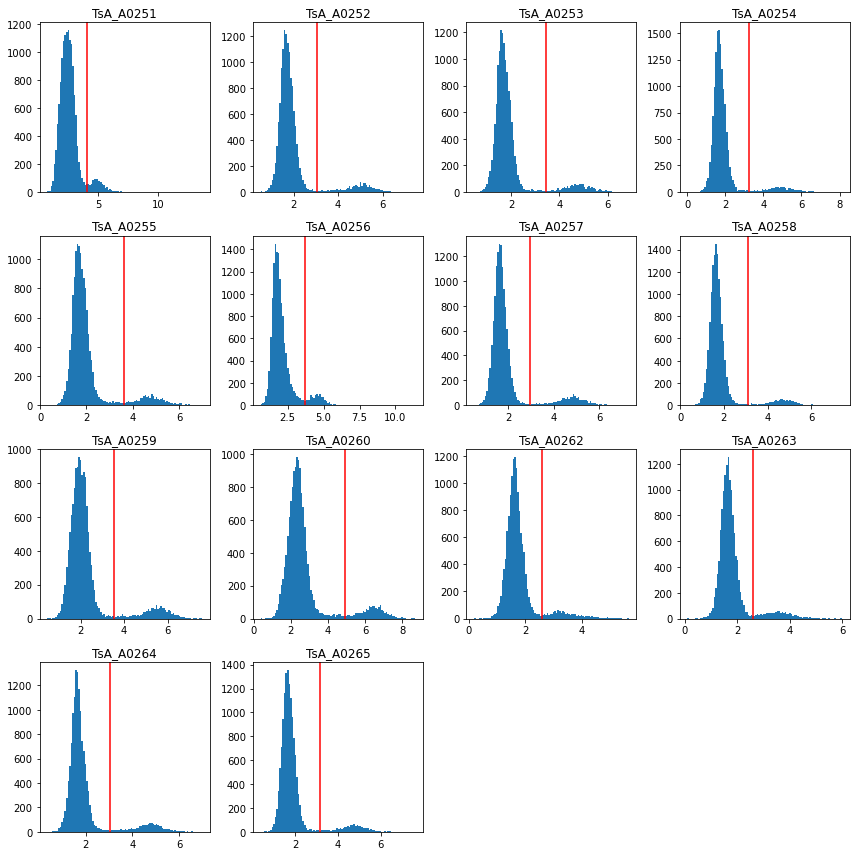

```python
demux.get_demux(ann, method='threshold')
```

```python
ann.obs['assignment'].value_counts()
```

```
Doublets     2711
TsA_A0257     951
TsA_A0264     915
TsA_A0259     908
TsA_A0260     835
TsA_A0255     831
TsA_A0262     785
TsA_A0253     777
TsA_A0263     775
TsA_A0252     773
TsA_A0265     754
TsA_A0256     695
Negative      641
TsA_A0258     628
TsA_A0251     608
TsA_A0254     582
Name: assignment, dtype: int64
```

### manually adjust threshold

sometimes threshold calling results might be off.  
we need to manually correct those thresholds.  
The threshold calling results are sotred in **ann.var['thre']**

```python
# setup manually assigned threshold in this section
ann.var.loc['TsA_A0260','thre'] = 4
```

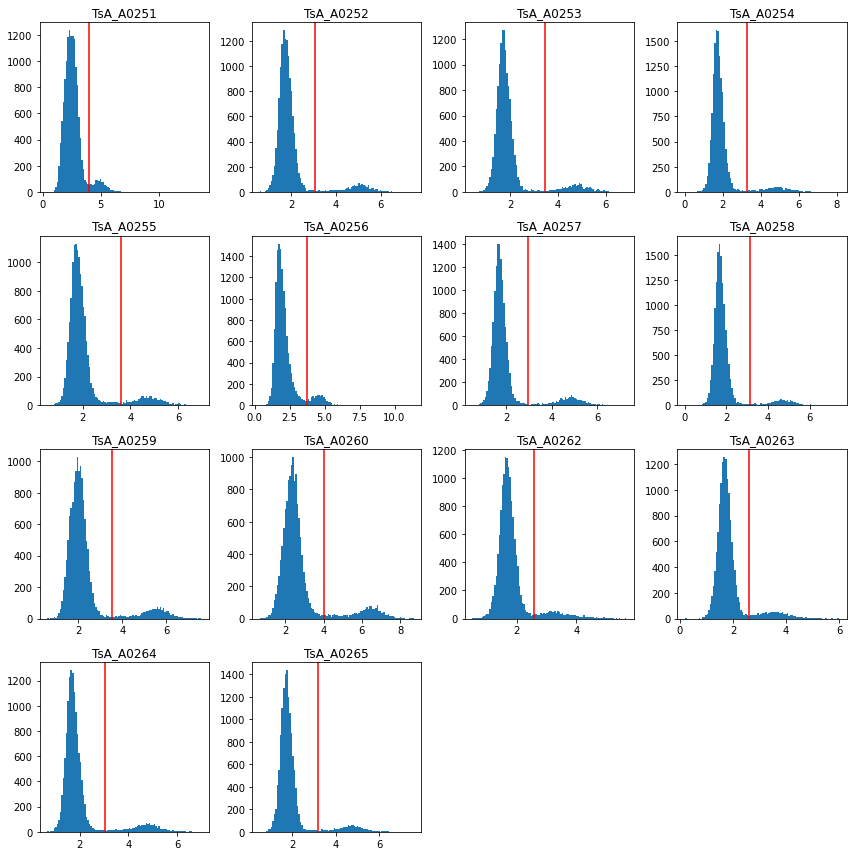

```python
demux.get_demux(ann, method='update')
```

```python
ann.obs['assignment'].value_counts()
```

```
Doublets     2877
TsA_A0257     935
TsA_A0264     901
TsA_A0259     893
TsA_A0260     855
TsA_A0255     816
TsA_A0262     779
TsA_A0253     767
TsA_A0252     757
TsA_A0263     757
TsA_A0265     748
TsA_A0256     687
TsA_A0258     621
Negative      608
TsA_A0251     594
TsA_A0254     574
Name: assignment, dtype: int64
```

## visualize demultiplexing results

### normalization

we use asinh transformed normalization result for further analysis including umap calculation  
This method add jittering noise to the expression before asinh transform to get flow like peak distributions  
HTO markers are annotated with ids starting with 'HTO'

```python
ann_hto = ann[:,['HTO' in t for t in ann.var['gene_ids']]].copy()
demux.asinh_trans(ann_hto)
```

### generate HTO ridge plots and umaps

with the normalized data, we can now calcuate umap based on HTO expression level

```python
# calculate HTO umap and attach it to raw data matrix as metadata
sc.pp.neighbors(ann_hto, n_neighbors=40, use_rep='X')
sc.tl.umap(ann_hto,min_dist=0.1)
```

plot demultplexed result on HTO umaps

```
... storing 'assignment' as categorical
... storing 'feature_types' as categorical
... storing 'genome' as categorical
```

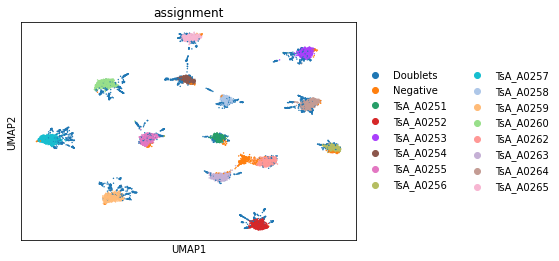

```python
sc.pl.umap(ann_hto,color='assignment')
```

The umap shows that clusgers of each hashtags are well separated, which indicates good distribution shape of hashtags  
expression level of each hashtag is also plotted below

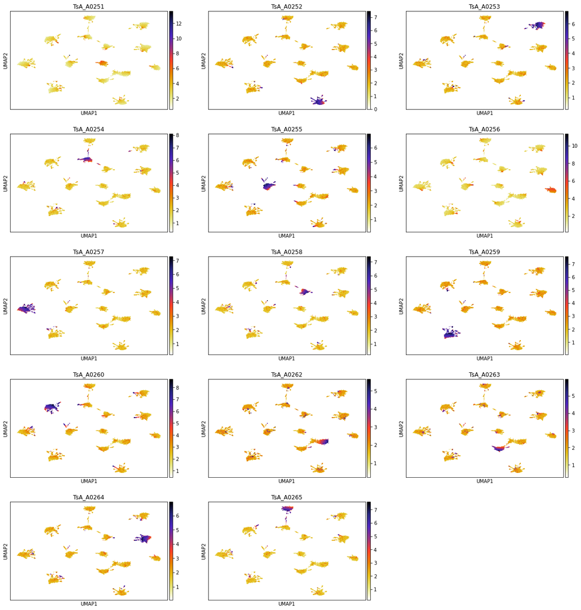

```python
sc.pl.umap(ann_hto,color=ann_hto.var_names, color_map='CMRmap_r', ncols=3)
```

ridge plot will also show the expression level difference between different cell assignment  
doublets will have positive counts for multiple hashtags, while negative cells will remain negative for all hashtags

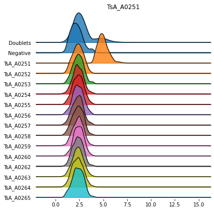

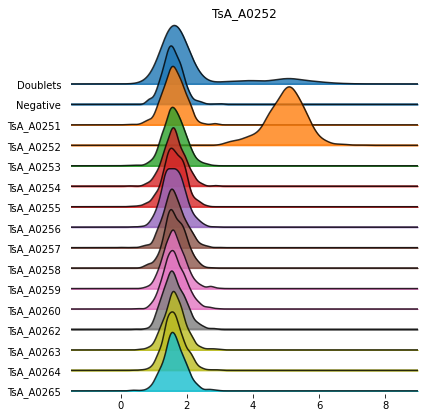

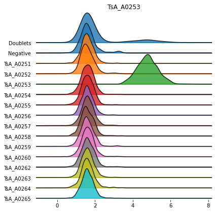

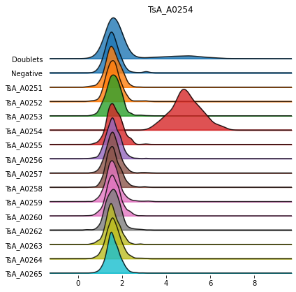

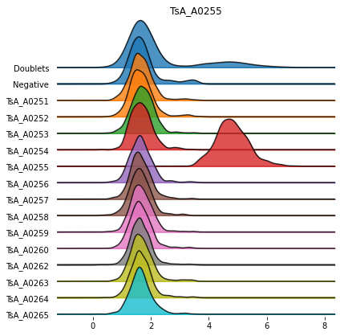

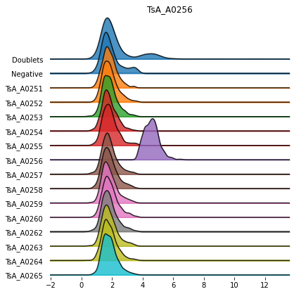

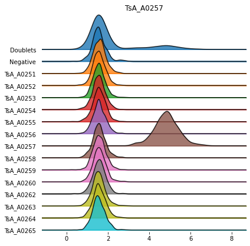

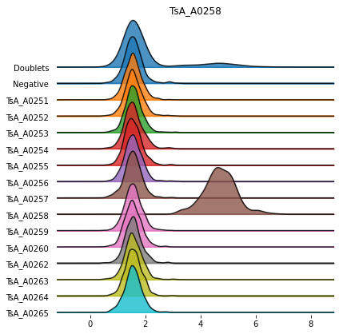

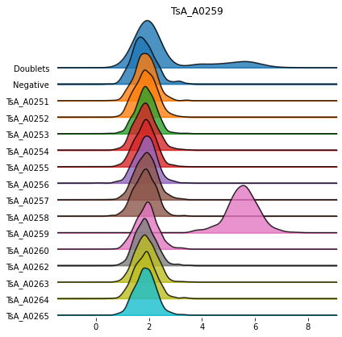

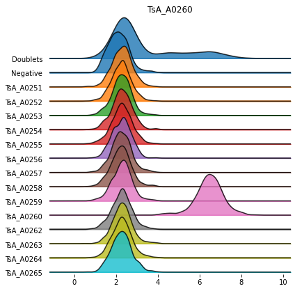

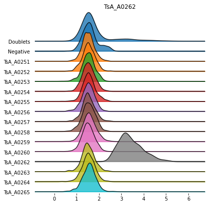

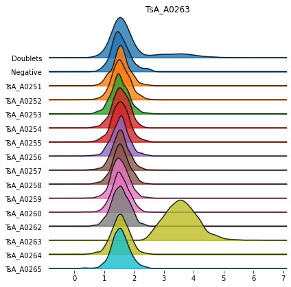

[2 more figures not shown]

```python
demux.get_ridge(ann_hto)
```

heatmap of expression level:  
A0260, A0259, and A0251 have relatively higher background according to the heatmap

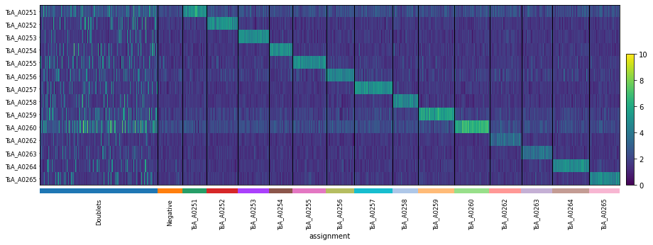

```python
sc.pl.heatmap(ann_hto,groupby='assignment',
              var_names=sorted(ann_hto.var_names),
              swap_axes=True, vmax=10,figsize=(15,5))
```

## filtering out doublets and negatives

```python
# filter out doublets and negatives
ann_single = ann[ann.obs['assignment']!='Negative',:]
ann_single = ann_single[ann_single.obs['assignment']!='Doublet',:].copy()
```

```python
# calculate umaps
ann_adt = ann_single[:,['ADT' in t for t in ann_single.var['gene_ids']]].copy()
demux.asinh_trans(ann_adt)
sc.pp.neighbors(ann_adt, n_neighbors=40, use_rep='X')
sc.tl.umap(ann_adt,min_dist=0.1)
```

ADT expression level plotted on ADT umaps are shown below,  
different cell type clusters are well separated

```
... storing 'assignment' as categorical
... storing 'feature_types' as categorical
... storing 'genome' as categorical
```

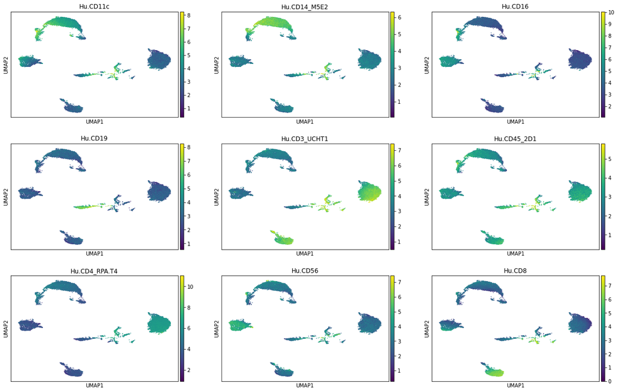

```python
sc.pl.umap(ann_adt, color=ann_adt.var_names, ncols=3)
```